# Lecture 211

2021-11-30

## Join operations

## Recap

**Prev**: Selection and manipulation

- Data frames and tibbles
- Data selection and filtering
- Data manipulation

**Now**: Join operations

- Joining data
- dplyr join functions

## Example

```r
cities <- data.frame(
  city_name = c("Barcelona", "London", "Rome", "Los Angeles"),
  country_name = c("Spain", "UK", "Italy", "US"),
  city_pop_M = c(1.62, 8.98, 4.34, 3.99)
)

cities_area <-data.frame(
  city_name = c("Barcelona", "London", "Rome", "Munich"),
  city_area_km2 = c(101, 1572, 496, 310)
)
```

## Example

| city_name | country_name | city_pop_M |
| --- | --- | --- |
| Barcelona | Spain | 1.62 |
| London | UK | 8.98 |
| Rome | Italy | 4.34 |
| Los Angeles | US | 3.99 |

| city_name | city_area_km2 |
| --- | --- |
| Barcelona | 101 |
| London | 1572 |
| Rome | 496 |
| Munich | 310 |

## Joining data

Tables can be joined (or ‘merged’)

- information from two tables can be combined
- specifying **column(s) from two tables with common values**
  - usually one with a unique identifier of an entity
- rows having the same value are joined
- depending on parameters
  - a row from one table can be merged with multiple rows from the other table
  - rows with no matching values in the other table can be retained
- `merge` base function or join functions in `dplyr`

## Join types

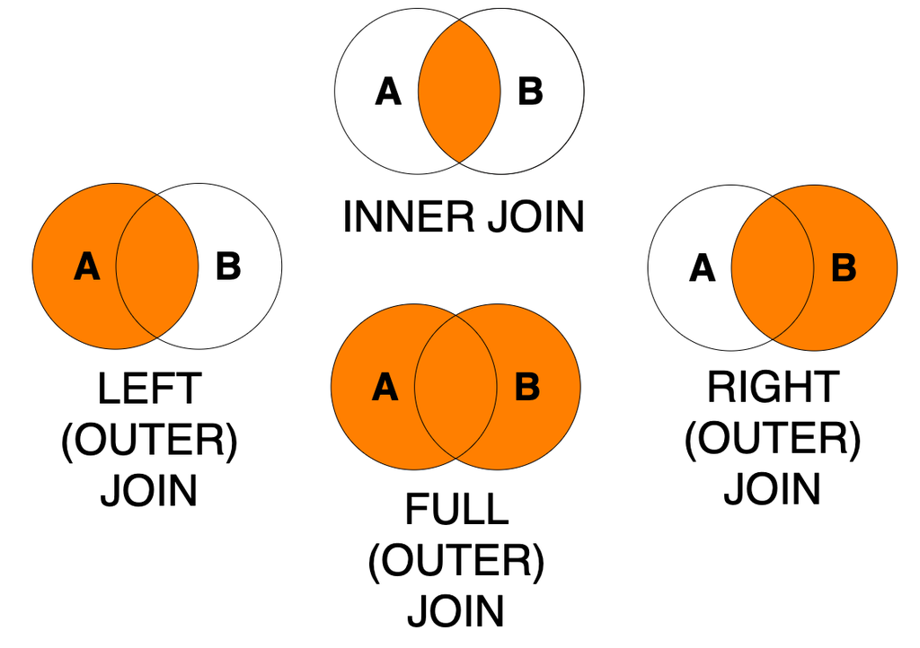

## dplyr joins

`dplyr` provides [a series of join verbs](https://dplyr.tidyverse.org/reference/join.html)

- **Mutating joins**
  - `inner_join`: inner join
  - `left_join`: left join
  - `right_join`: right join
  - `full_join`: full join
- **Nesting joins**
  - `nest_join`: all rows columns from left table, plus a column of tibbles with matching from right
- **Filtering joins** (keep only columns from left)
  - `semi_join`: , rows from left where match with right
  - `anti_join`: rows from left where no match with right

## dplyr::full_join

- `full_join` combines all the available data

```r
dplyr::full_join(
  # first argument, left table
  # second argument, right table
  cities, cities_area,
  # specify which column to be matched
  by = c("city_name" = "city_name")
  )
```

| city_name | country_name | city_pop_M | city_area_km2 |
| --- | --- | --- | --- |
| Barcelona | Spain | 1.62 | 101 |
| London | UK | 8.98 | 1572 |
| Rome | Italy | 4.34 | 496 |
| Los Angeles | US | 3.99 | NA |
| Munich | NA | NA | 310 |

## Pipes and shorthands

When using (all) join verbs in `dplyr`

```r
# using pipe, left table is "coming down the pipe"
cities %>%
  dplyr::full_join(cities_area, by = c("city_name" = "city_name"))

# if no columns specified, columns with the same name are matched
cities %>%
  dplyr::full_join(cities_area)
```

| city_name | country_name | city_pop_M | city_area_km2 |
| --- | --- | --- | --- |
| Barcelona | Spain | 1.62 | 101 |
| London | UK | 8.98 | 1572 |
| Rome | Italy | 4.34 | 496 |
| Los Angeles | US | 3.99 | NA |
| Munich | NA | NA | 310 |

## dplyr::left_join

- keeps all the data from the **left** table
  - first argument or *“coming down the pipe”*
- rows from the right table without a match are dropped
  - second argument (or first when using *pipes*)

```r
cities %>%
  dplyr::left_join(cities_area)
```

| city_name | country_name | city_pop_M | city_area_km2 |
| --- | --- | --- | --- |
| Barcelona | Spain | 1.62 | 101 |
| London | UK | 8.98 | 1572 |
| Rome | Italy | 4.34 | 496 |
| Los Angeles | US | 3.99 | NA |

## dplyr::right_join

- keeps all the data from the **right** table
  - second argument (or first when using *pipes*)
- rows from the left table without a match are dropped
  - first argument or *“coming down the pipe”*

```r
cities %>%
  dplyr::right_join(cities_area)
```

| city_name | country_name | city_pop_M | city_area_km2 |
| --- | --- | --- | --- |
| Barcelona | Spain | 1.62 | 101 |
| London | UK | 8.98 | 1572 |
| Rome | Italy | 4.34 | 496 |
| Munich | NA | NA | 310 |

## dplyr::inner_join

- keeps only rows that have a match in **both** tables
- rows without a match either way are dropped

```r
cities %>%
  dplyr::inner_join(cities_area)
```

| city_name | country_name | city_pop_M | city_area_km2 |
| --- | --- | --- | --- |
| Barcelona | Spain | 1.62 | 101 |
| London | UK | 8.98 | 1572 |
| Rome | Italy | 4.34 | 496 |

## dplyr::semi_join and anti_join

```r
cities %>%
  dplyr::semi_join(cities_area)
```

| city_name | country_name | city_pop_M |
| --- | --- | --- |
| Barcelona | Spain | 1.62 |
| London | UK | 8.98 |
| Rome | Italy | 4.34 |

```r
cities %>%
  dplyr::anti_join(cities_area)
```

| city_name | country_name | city_pop_M |
| --- | --- | --- |
| Los Angeles | US | 3.99 |

## Summary

Join operations

- Joining data
- dplyr join functions

**Next**: Tidy-up your data

- Wide and long data
- Re-shape data
- Handle missing values